# **How to Use: Report Builder Tool**

KuskoHarvEst Documentation

Package Version: 1.1.1.9990

Last Updated: 5/29/2023

*This document describes how to use the report builder tool, where you will select which content to display in the output reports and build them.*

This tool helps you build two documents:

- **In-Season Estimate Report**: which summarizes key features of the input data and output estimates for consideration by managers and stakeholders.
- **Sensitivity Analysis Report**: which summarizes output from various analyses that leave out chunks of data and recalculate the estimates. These kinds of analyses give you an idea of how robust the estimate you obtained was based on the data, but are not generally shared outside of the team of people conducting technical reviews of the estimates.

**Steps to Complete Before Using this Tool**:

1. Create a new R project (instructions here)
2. Organize the raw data files and place them in the `data-raw` folder of your project (instructions here)
3. Enter the opportunity meta-data (instructions here)
4. Prepare the raw data files into a standardized format (instructions here)

After you have completed these steps, you are ready to proceed with building the reports. Navigate to the RStudio addins menu, and select the highlighted option:

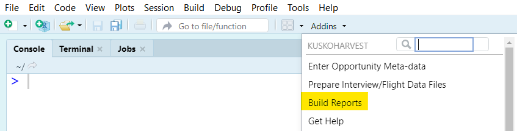

This window will open within RStudio:

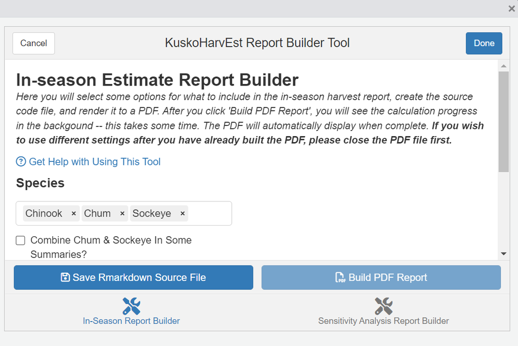

Clicking the link that says “Get Help with Using this tool” will open this document.

**NOTE**: this tool checks to make sure you have completed the steps leading up to it, and will return errors if it detects a problem.

- If you attempt to do this step without having first completed the meta-data entry step, you will receive this error:

  ```
  Error: No meta-data file detected - you must run the meta-data tool before using this tool.
  ```

- If you attempt to do this step but have not properly completed the interview data preparation steps, you will receive this error:

  ```
  Error: No interview data file detected - you must run the interview/flight data tool before this tool.
  ```

- If you attempt to do this step but have not properly completed the flight data preparation steps, you will receive this error:

  ```
  Error: No flight data file detected - you must run the interview/flight data tool before this tool.
  ```

## In-Season Report Builder Tab

First, ensure you are on this tab of the tool:

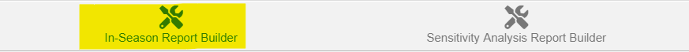

First, select which species to produce estimates for:

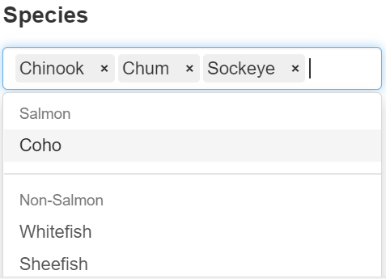

You **must** select at least one salmon species but selecting any of the nonsalmon species is optional. If no harvest data exist for a selected species, the returned harvest estimate will be zero.

If you selected both chum and sockeye salmon, you may check this box to present a combined “Chum+Sockeye” category (rather than separately by species) in the appendix and histogram content of the report:

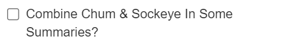

Next, you will need to check or uncheck these boxes to control what content you want to include in the output document:

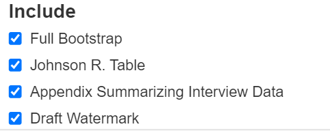

Here is what each item controls:

- **Full Bootstrap**: If checked, the bootstrap algorithm (how uncertainty is estimated) will be executed for the complete duration. This may take a minute or two; uncheck this box for testing and drafting the document and you will see the output more quickly.
- **Draft Watermark**: If checked, this will include a “Draft” watermark on each page of the document, indicating that it is not yet considered finalized. When you are ready to make the estimate final, run the tool with this box unchecked. Note that the draft watermark is required if not executing the full bootstrap.
- **Johnson R. Table**: If checked, a table summarizing effort, catch rates, and species composition upstream and downstream of the Johnson R. confluence will be included. Note that this option is only available if drift net harvest is included.
- **Appendix Summarizing Interview Data**: If checked, a set of tables summarizing interview quantities across different geographic strata will be displayed at the end of the document. Uncheck this box if you do not wish to display this content.

When you are done selecting these options, click the “Save Rmarkdown Source File” button and then the “Build PDF Report” button (note that you cannot click the second button without clicking the first button).

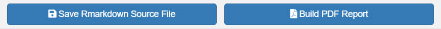

After you click “Build PDF Report”, you will see some text appear in the R console behind the tool indicating that calculations are happening. When these are complete, a PDF file will automatically be opened showing you the results.

**If you wish to make changes to the PDF file after it has already been created, close the PDF file if it is still open, re-select the correct settings, then click both buttons again.**

You can find several new files in your project folder now:

- `KuskoHarvEst_YYYY_MM_DD.Rmd`: This is the Rmarkdown source file that gets created automatically (or overwritten if it already exists) when you click “Save Rmarkdown Source File”. It contains the code to run the estimation analysis and is formatted to produce a nice PDF report. You should not need to edit this file by hand, but if you know what you are doing and you would like to do so, you are recommended to save it under a different file name first. This will prevent your manual changes from being overwritten if you run the report builder tool again.
- `output/KuskoHarvEst_YYYY_MM_DD.pdf`: This is the PDF output file.
- `output/KuskoHarvEst_bootstrap_YYYY_MM_DD.csv`: This file contains the individual bootstrap values of harvest estimates. This file may be requested from you by the person who creates the in-season assessment documents.

## Sensitivity Analysis Report Builder Tab

To build the sensitivity analysis document, navigate to this tab:

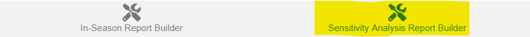

where you will find this page:

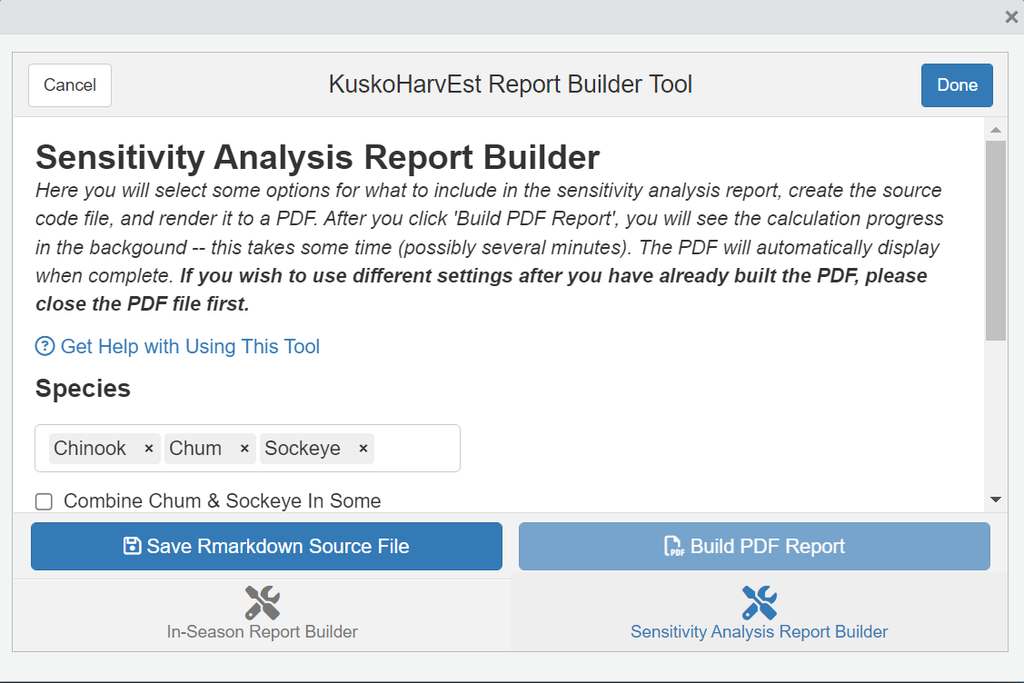

This part of the tool works very similarly to the previous tab, so consult that section of this document for details on exactly how to use it. The calculations behind sensitivity analyses take quite a bit longer than for the main document, so be prepared to wait several minutes if you have selected to run the full bootstrap.

You cannot produce the sensitivity analysis for nonsalmon species or if the opener allowed set nets only.

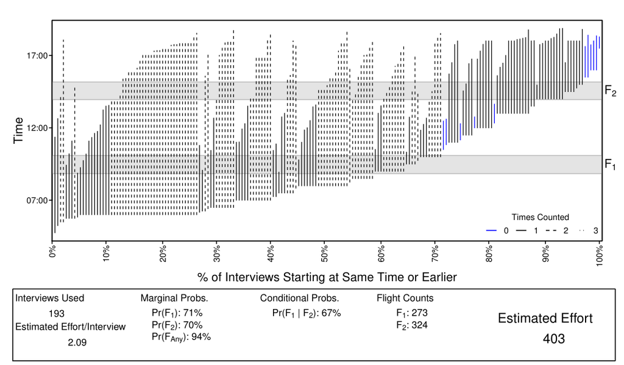

These figures are useful, but don’t display any critical information that isn’t already summarized in the other tables within the output document. Thus, their inclusion is optional.

When you are done building the reports, you may click the “Done” button at the top right to exit the tool.